# OkCupid Dating Data Analysis

Jason Jia

7/22/2019

An in-depth exploratory data analysis and visulization of site users of okcupid.com

I examined,cleaned and eriched the data with supplemental data. I discovered some fun facts throught the EDA steps.

*Data Source: https://www.researchgate.net/project/The-OKCupid-dataset-A-very-large-publicdataset-of-dating-site-users

```r
setwd("~/Data Analyst Pathway/Data mining with BA in R/Case study 1")
rm(list=ls())
```

```r
library(okcupiddata)
library(ggplot2)
library(dplyr)
library(maps)
library(forecast)
library(ggthemes)
```

```r
data('profiles')
coord = read.csv('LatLon.csv') #city coordinates
addr = read.csv('addr.csv') #get zip, city, county, and state
census = read.csv('sharedCensus2010Vars.csv') #tons of race dummies
```

#TODO: add basic age and sex by sexual orientation histogram

#TODO: correct population values with na.omit()

```r
#calculates poplation per county
counties = data.frame(county = 1:length(unique(census$county)), county.pop = 1:length(unique(census$county)))
profiles = left_join(profiles, addr, by='location')
profiles = left_join(profiles, coord, by='location')
location.population = census[,c(1,6)]
addr = left_join(addr, location.population, by='location')
addr$population = addr$P0010001_Total_population
addr$P0010001_Total_population = NULL

for(i in 1:length(unique(census$county))){
  counties$county[i] = as.character(unique(census$county)[i])
  pop = addr[addr$county==counties$county[i],]
  counties$county.pop[i] = sum(pop$population, na.rm = T)
}
```

Let’s engineer a variable to simplify pet ownership status.

```r
#Pets: split into three categories, have, don't have but want, don't want
like_pets = unique(profiles$pets)[c(1,3,7,10)]
dislike_pets = unique(profiles$pets)[c(13,14,15,16)]
has_pets = unique(profiles$pets)[c(2,5,6,8,9,11,12)]
for (i in 1:nrow(profiles)){
if(profiles$pets[i] %in% has_pets){
  profiles$pet_factor[i] = 'Has Pets'
}
if(profiles$pets[i] %in% dislike_pets){
  profiles$pet_factor[i] = 'Dislikes Pets'
}
if(profiles$pets[i] %in% like_pets){
  profiles$pet_factor[i] = 'Likes Pets'
}
}
```

Now let’s do the same for simplifying a users offspring status.

```r
#Kids: split into three categories, have, don't have but want, don't want
has_kids = unique(profiles$offspring)[c(7,8,10,11,12,13,15,16)]
wants_kids = unique(profiles$offspring)[c(1,4,6,14)]
dislike_kids = unique(profiles$offspring)[c(3,5,9)]
for (i in 1:nrow(profiles)){
  if(profiles$offspring[i] %in% has_kids){
    profiles$kids[i] = 'Has Kids'
  }
  if(profiles$offspring[i] %in% wants_kids){
    profiles$kids[i] = 'Wants Kids'
  }
  if(profiles$offspring[i] %in% dislike_kids){
    profiles$kids[i] = 'Does Not Want Kids'
  }
}
```

We will use these two variables later in the analysis.

```r
num_users = 1:nrow(counties)
#calculate users per county
for(i in 1:nrow(counties)){
  x = profiles[profiles$county==counties$county[i],]
  num_users[i] = nrow(x)
}
#add users per county to the county dataframe
counties$num_users = num_users
counties = counties[complete.cases(counties),]
```

```r
#calculate proportion of counties using okcupid
counties = counties[counties$county.pop>0,]
counties$okcupid_proportion = counties$num_users / counties$county.pop
```

### Insight #1: LGBT community

We are interested in finding the areas with the highest populations of LGBT users.

Here let’s calculate the number of LGBT users in each county.

```r
lgbt = profiles[(profiles$orientation=='bisexual')|(profiles$orientation=='gay'),]
counties$lgbt_users = 0
for(i in 1:nrow(counties)){
  x = lgbt[lgbt$county==counties$county[i],]
  counties$lgbt_users[i] = nrow(x)
}
counties$lgbt_proportion = counties$lgbt_users / counties$num_users
```

```r
head(counties[order(counties$lgbt_proportion, decreasing = T),], 6)
```

```
##                  county county.pop num_users okcupid_proportion lgbt_users
## 2        Alameda County     498968     17179        0.034429062       2586
## 3  San Francisco County     110583     33193        0.300163678       4894
## 5   Contra Costa County     505374      5220        0.010328984        452
## 8         Solano County      96887      2890        0.029828563        249
## 1      San Mateo County     678103      7616        0.011231332        615
## 14   Los Angeles County     316050      2159        0.006831198        170
##    lgbt_proportion
## 2       0.15053263
## 3       0.14744073
## 5       0.08659004
## 8       0.08615917
## 1       0.08075105
## 14      0.07874016
```

As we can see, they are all in California. Let’s map all the LGBT users in these 6 counties.

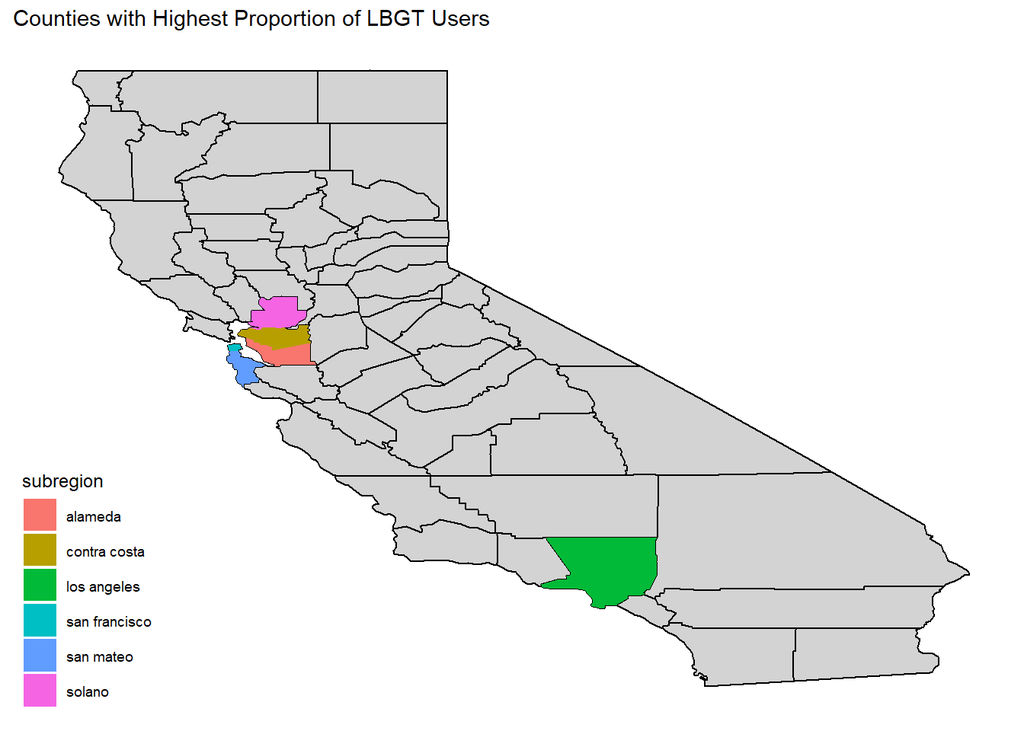

```r
countyData = map_data('county')
california = countyData[countyData$region=='california',]
selectedCounties = trimws(tolower(head(counties[order(counties$lgbt_proportion, decreasing = T),1], 6)), which='right', whitespace = ' county')
ggplot()+
  geom_polygon(data=california, aes(x=long, y=lat, group=subregion),color='black', fill='lightgrey') +
  geom_polygon(data=california[california$subregion %in% selectedCounties,], aes(x=long, y=lat, group=subregion, fill=subregion))+
  labs(title='Counties with Highest Proportion of LBGT Users')+
  theme_map()
```

Now let’s see how orientation is distributed within these 6 counties.

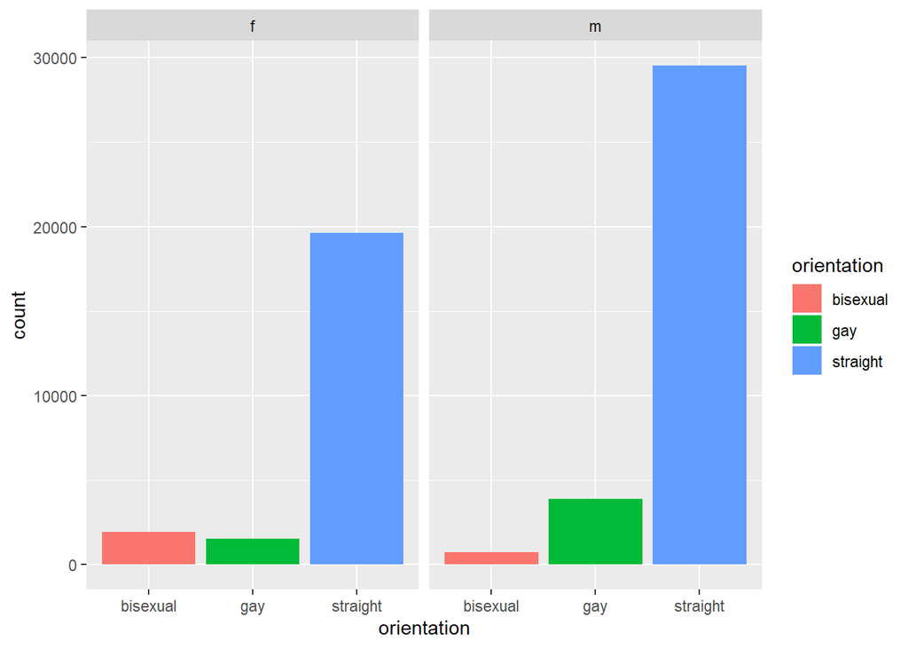

```r
lgbt_counties = head(counties[order(counties$lgbt_users, decreasing = T),1], 6)
all_users.lgbt_counties = profiles[profiles$county %in% lgbt_counties,]
ggplot(all_users.lgbt_counties) +
  geom_bar(aes(x=orientation, fill=orientation), stat='count') +
  facet_wrap(~sex)
```

### Insight #2: Low users in a high population area

We were also interested in targeting markets with a high potential for user growth. So we sought to identify counties with high populations, but low number of users.

```r
#first I'm going to add state to our counties df
for(i in 1:nrow(counties)){
  x = census[census$state==counties$county[i],]
  counties$state = census$state[1]
}
```

For simplicity, we are going to only search for growth opportunities in California.

```r
#subset on california only
calif.counties = counties[counties$state=='California',]
#grab names of counties where proportion of users is low
low_user_counties = trimws(tolower(head(calif.counties[order(calif.counties$okcupid_proportion, decreasing = F),1])), which = 'right', whitespace = ' county')
```

Now that we have our subset of data, let’s see which areas can increase their user proportion.

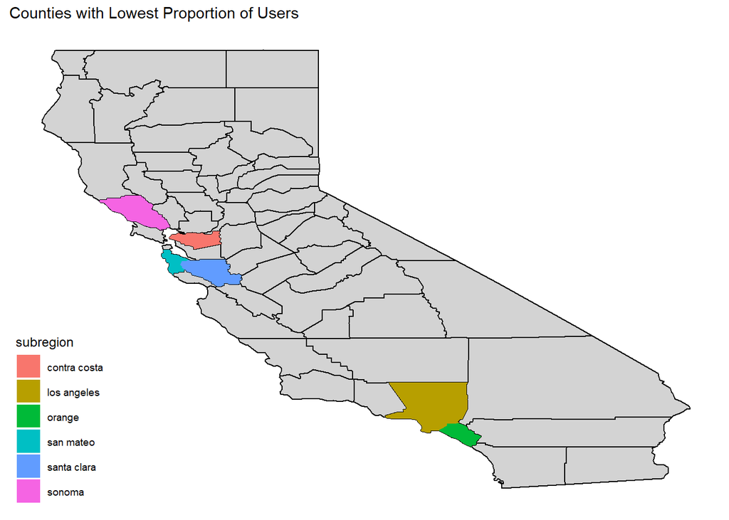

```r
ggplot()+
  geom_polygon(data=california, aes(x=long, y=lat, group=subregion), color='black', fill='lightgrey') +
  geom_polygon(data=california[california$subregion %in% low_user_counties,], aes(x=long, y=lat, group=subregion, fill=subregion))+
  labs(title='Counties with Lowest Proportion of Users') +
  theme_map()
```

### Insight #3: High income areas

We wanted to look into high income areas, where we can possibly entice wealthy users to buy more expensive features on our app. But first let’s get a better idea of what incomes looks like for our California users.

```r
#again, let's subset only for california
calif.profiles = profiles[profiles$state=='California',]
print('Proportion of Californian Users Reporting Income')
```

```
## [1] "Proportion of Californian Users Reporting Income"
```

```r
sum(is.na(calif.profiles$income)) / nrow(calif.profiles)
```

```
## [1] 0.8147845
```

Over 80% of Californian users didn’t report income.

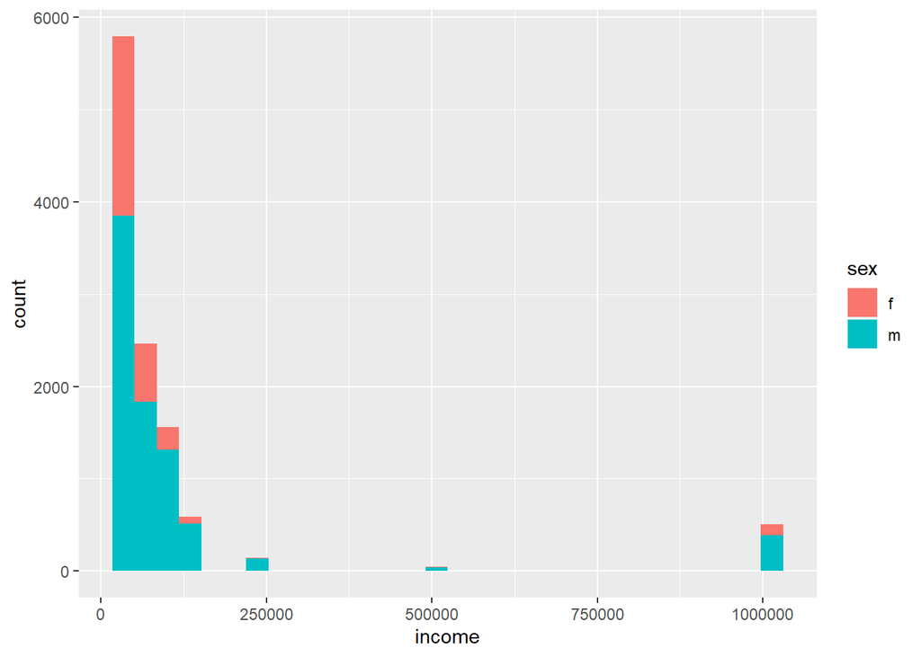

```r
ggplot() +
  geom_histogram(data=calif.profiles, aes(x=income, fill=sex))
```

We have quite a few reported millionaires in our dataset.

Let’s see where they live.

```r
millions = calif.profiles[na.omit(calif.profiles$income>999999),]
counties$millionaires = 0

for (i in 1:nrow(counties)){
  counties$millionaires[i] = nrow(millions[na.omit(millions$county==counties$county[i]),])
}

millionaire.counties = counties[na.omit(counties$millionaires>0),]
```

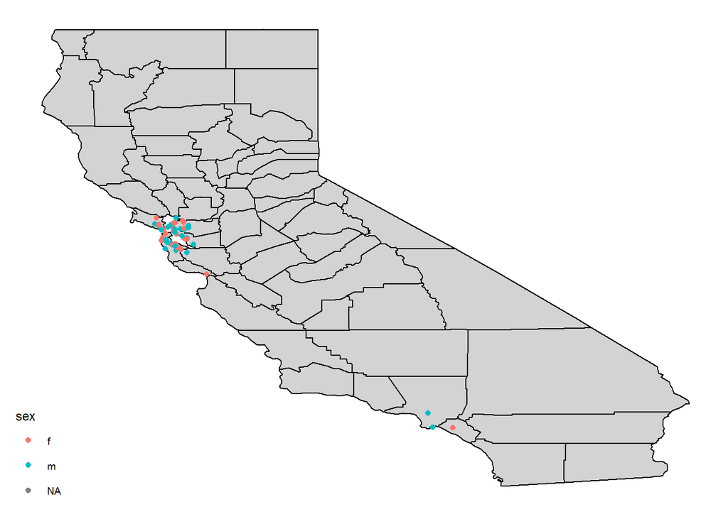

```r
ggplot() +
  geom_polygon(data=california, aes(x=long, y=lat, group=subregion), fill='lightgrey', color='black') +
  #I want to plot the counties with millionaires with alpha as number of millionaires
  #geom_polygon(data=california[california$subregion %in% millionaire.counties], aes(x=long, y=lat, alpha=))
  geom_point(data=millions, aes(x=lon, y=lat, color=sex))+
  theme_map()
```

High user activity characteristics, then find similar town We would like to look for a county with a very high user proportion, then look for a comprable county with low user engagement as an ‘up and coming’ neighborhood.

```r
head(counties[order(counties$okcupid_proportion, decreasing = T),])
```

```
##               county county.pop num_users okcupid_proportion lgbt_users
## 40      Hinds County        536      2129          3.9720149        162
## 33       Cook County       1204      2134          1.7724252        164
## 46      Bexar County       1453      2129          1.4652443        162
## 34 Barnstable County       2580      2129          0.8251938        162
## 43   Hennepin County       2604      2130          0.8179724        162
## 63    Jackson County       3505      2129          0.6074180        162
##    lgbt_proportion      state millionaires
## 40      0.07609206 California            0
## 33      0.07685098 California            0
## 46      0.07609206 California            0
## 34      0.07609206 California            0
## 43      0.07605634 California            0
## 63      0.07609206 California            0
```

Looks like the data isn’t perfectly clean. Let’s remove counties with a popluation of zero and recalculate.

```r
counties.clean = counties[counties$county.pop>0,]
head(counties.clean[order(counties.clean$okcupid_proportion, decreasing = T),])
```

```
##               county county.pop num_users okcupid_proportion lgbt_users
## 40      Hinds County        536      2129          3.9720149        162
## 33       Cook County       1204      2134          1.7724252        164
## 46      Bexar County       1453      2129          1.4652443        162
## 34 Barnstable County       2580      2129          0.8251938        162
## 43   Hennepin County       2604      2130          0.8179724        162
## 63    Jackson County       3505      2129          0.6074180        162
##    lgbt_proportion      state millionaires
## 40      0.07609206 California            0
## 33      0.07685098 California            0
## 46      0.07609206 California            0
## 34      0.07609206 California            0
## 43      0.07605634 California            0
## 63      0.07609206 California            0
```

```r
df = data.frame(number_users = unique(counties.clean$num_users), frequency.of.number= 1:length(unique(counties.clean$num_users)))
for (i in 1:nrow(df)){
  df$frequency.of.number[i] = nrow(counties[counties$num_users==df$number_users[i],])
}
(df)
```

```
##    number_users frequency.of.number
## 1          7616                   1
## 2         17179                   1
## 3         33193                   1
## 4          3944                   1
## 5          5220                   1
## 6          2520                   1
## 7          2890                   1
## 8          2134                   4
## 9          2133                   1
## 10         2129                  46
## 11         2138                   1
## 12         2132                   1
## 13         2159                   1
## 14         2130                  10
## 15         2131                   2
```